# Reproducible Research: Peer Assessment 1

# Introduction

This is the peer assignment 1 of the course RepData. The opts used in this R-Markdown is:

```r
library(knitr)
opts_chunk$set(echo=TRUE)
```

## Loading and preprocessing the data

Loading data using `read.csv`

```r
if(!exists("activity.csv"))unzip("activity.zip")
data <- read.csv("activity.csv",head=T,na.strings="NA")
```

## What is mean total number of steps taken per day?

Making a histogram of the total number of steps taken each day, ignoring NA values

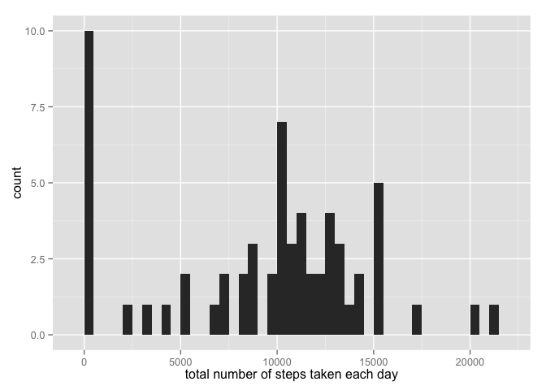

```r
library(ggplot2)
data.totalsteps<-tapply(data$steps,data$date,FUN=sum,na.rm=T)
qplot(data.totalsteps,binwidth=500,xlab="total number of steps taken each day")
```

The **mean** and the **median** of total number of steps taken per day

```r
mean(data.totalsteps,na.rm = T)
```

```
## [1] 9354.23
```

```r
median(data.totalsteps,na.rm = T)
```

```
## [1] 10395
```

## What is the average daily activity pattern?

Time series plot of 5-minute interval and the average number of steps taken, avergaed across all days

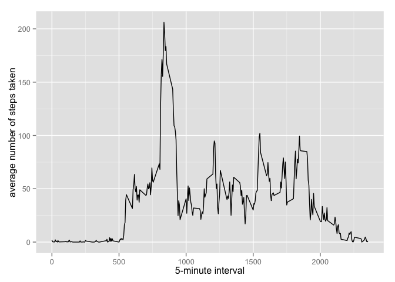

```r
avg <- aggregate(x=list(steps=data$steps),by=list(interval=data$interval),FUN = mean, na.rm = T)

ggplot(data=avg,aes(x=interval,y=steps)) +
  geom_line() +
  xlab("5-minute interval")+
  ylab("average number of steps taken")
```

The maximun number of steps on 5-minute interval on average across all the days

```r
avg[which.max(avg$steps),]
```

```
##     interval    steps
## 104      835 206.1698
```

## Imputing missing values

```r
nai <- is.na(data$steps)
#sum of missing
sum(nai)
```

```
## [1] 2304
```

Replacing strategy is to replace the NA with the mean of the interval for that day

```r
rnwm <- function(steps, interval){
  result <- NA
  if(!is.na(steps))
    result<-c(steps)
  else
    result<-(avg[avg$interval==interval,"steps"])
  result
}
data.replaced <- data
data.replaced$steps <- mapply(rnwm, data.replaced$steps, data.replaced$interval)
```

Plotting histogram on the newly created dataset, reporting the **mean** and the **median** total number of steps taken each day.

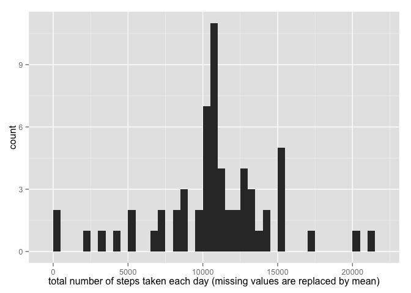

```r
data.replaced.totalsteps <- tapply(data.replaced$steps, data.replaced$date, FUN=sum)
qplot(data.replaced.totalsteps,binwidth=500,xlab="total number of steps taken each day (missing values are replaced by mean)")
```

```r
#mean
mean(data.replaced.totalsteps)
```

```
## [1] 10766.19
```

```r
#median
median(data.replaced.totalsteps)
```

```
## [1] 10766.19
```

The **mean** and **median** are both greater than previous analysis because we imputed the previous supposed `"0"`s with average total daily steps

## Are there differences in activity patterns between weekdays and weekends?

On the newly imputed dataset, we introduce 2 factor(group) `"weekday"` and `"weekend"`. And then we plot a time series of the 5-minute interval and average number of steps taken, averaged across all weekdays and weekends.

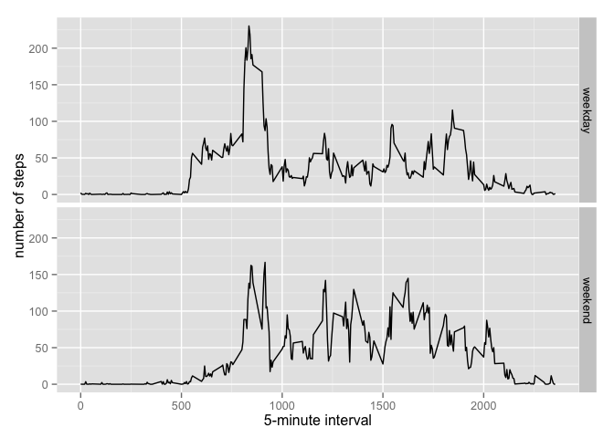

```r
weekday <- function(date){
  day<- weekdays(date)
  if (day %in% c("Monday","Tuesday","Wednesday","Thursday","Friday"))
    return ("weekday")
  else if(day %in% c("Saturday","Sunday"))
    return("weekend")
  else stop("invalid date")
}
data.replaced$date <- as.Date(data.replaced$date)
data.replaced$day <- sapply(data.replaced$date,FUN=weekday)

avgwd <- aggregate(steps~interval+day,data = data.replaced, mean)
ggplot(avgwd,aes(interval,steps))+
  geom_line() +
  facet_grid(day~.) +
  xlab("5-minute interval") +
  ylab("number of steps")
```